# ABI - land-use intensity index

[NO_ABIN_001] (Mountains)

Author

Affiliation

Anders Kolstad

Norwegian Institute for Nature Research

Published

September 4, 2026

Reviewed by

Pre-published version - No code review performed

> **Recommended citation**: Kolstad, A. 2026. Land-use intensity (ID(s): NO_ABIN_001) v. 0.1.0. ecRxiv: https://github.com/NINAnor/ecRxiv/tree/main/indicators/NO_ABIN_001

**Metadata**

Table 1: Indicator metadata

| Variable | Value |
| --- | --- |
| Indicator ID | NO_ABIN_001 |
| Indicator Name | Land-use intensity |
| verbatimName | Arealbruksintensitet |
| Country | Norway |
| Continent | Europe |
| Ecosystem Condition Typology Class | C1 |
| Realm | Terrestrial (T) |
| Biome | T3 Shrublands and shrubby woodlands biome; T6 Polar-alpine (cryogenic) biome |
| Ecosystem | NA |
| verbatimEcosystem | Fjell |
| Year added | 2026 |
| Last update | 2026 |
| Version | 0.1.0 |
| Version comment | This is a pre-released version of this workflow and it has not yet been code-reviewed. |
| Normalised | FALSE |
| Spatial aggregation pathway | Aggregate (geographic regions) |
| Precision | No precision estimates are reported |

**Log**

- 04 September 2026 - Started working

## 1. Summary

1. **Background and rationale**: Ecosystems and their species communities are dependent on movement of individuals and genes in order to maintain the ecological integity and functioning. Fragmentation reduces the ability of some species to move through the landscape, and this fragmentation can take the form of both physical barriers as well as any disturbance that alterns species behavours i was that makes some areas less accessible. How sensitive the species are to fragmentation varies widely. Generally, large mammals are the most susceptible group. Ecosystem condition indicators should ideally not represent pressures or drivers directly, but in the absence of good and religable data on landskape connectivity, fragmentation, asa condition variable, is used here as a proxy.
2. **Methods**: The underlying dataset is called land-use intensity index, or ABI in the Norwegian abbreviation, and is an index representing the amount of technical infrastructur within an area. The index values are calcualted for all 25 m grid cells inside the Norwegian mainland. The types of infrastructur that affect the index are: physical construction, arificial surfaces and ‘other’ human impact. This last category include regulated water bodies, tractor road and agricultural lands. The data is available for the year 2017 and 2025. The data is masked to include only mountain areas, and variable is then taking the mean value for each of the five geographic regions in Norway, as well as for all of Norway
3. **Interpretation**: High values represenet higher presence of human infrastructure and land-use related disturbances, than smaller values do. The absolute value of the variable can be compared between regions. Within a region, the development over time tells us if human-cause fragmentation is increasing or decreasing in that area.
4. **Results and development needs**: The land use intensity index in Norwegian mountains has risen slightly between 2017 and 2025, but it is difficult to asses how severe this trend is. The index values are highest in western Norway, and lowest in central Norway. The workflow and cpondition variable would benefit from better temporal resolution, and a copmparison against other ecosystems.

## 2. About the underlying data

This workflow used the land use intensity index for Norway (Erikstad et al. 2023). In Norwegian it is called *arealbruksintensitet*; hance the abbreviation ABI. The data is slightly different than the version reported in Erikstad et al. (2023). It is range-normalised to values between 0 and 1. It also includes in its calculations the presence of agriculture and regulated lakes.

### 2.1 Spatial and temporal resolution and extent

The data is available from 2017 and 2025 but there is considerable time lag in how the raw, underlying data is updates.

### 2.2 Sampling design

The sampling is complete, wall-to-wall, but to speed up calculations I have resampled a certain number of raster cells to calculate area statistics from.

### 2.3 Original units

The units are arbitrary.

### 2.4 Instructions for citing, using and accessing data

the method and data can be sited as Erikstad et al. (2023). The data will be made available upon request.

### 2.5 Additional comments about the dataset

Many version exist of this dataset, with different resolutions and different human interventions being included in the index calculations.

## 3. Indicator properties

### 3.1 Ecosystem Condition Typology Class (ECT)

This is an ecosystem condition variable or a proxy of such, and belong in the C1 - landscape characteristics class.

### 3.2 Ecosystem condition characteristic

The variable represents landscape fragmentation, or i works as a coarse proxy for landscape connectivity.

### 3.3 Collinearities with other indicators

None.

### 3.4 Impact factors

The variable (index) is sensitive to any human infrastructure or activity that is captured in the index, such as roads, buildings and agriculture.

### 3.5 Spatial aggregation

The data is aggregated with an arithmetic mean for each region.

## 4. Reference condition and levels

### 4.1 Reference condition

Not relevant

### 4.2 Reference levels

Not relevant

#### 4.2.1 Spatial resolution and validity

Iinterprettable at the scale of geographic regions (as is reported).

## 5. Uncertainties

### 5.1 General uncertainties

Not assessed.

### 5.2 Reported uncertainties

No uncertainties are reported for this variable.

## 6. References

## 7. Import and prepare datasets

Importing the ABI data, an ecosystem delineatoiun mask, and a deliminatior file for the five geographical regions.

```r
if (grepl("/data/", getwd())){
  root <- "/data/P-Prosjekter2/172520_utvikling_av_forstyrrelsesindeks/ABI/Jenny/ABI/output/abi_exports/"
}else{
  root <-  "P:/172520_utvikling_av_forstyrrelsesindeks/ABI/Jenny/ABI/output/abi_exports/"
}

pathReg <- here::here("data/regions.rds")
path17 <- paste0(root, "2017/ABI_2017_enkel_v1_norm.tif")
path25 <- paste0(root, "2025/ABI_2025_enkel_v1_norm.tif")
pathMask <- here::here("data/fjellmasken.tif")
```

```r
reg <- readRDS(pathReg)
data17t <- terra::rast(path17)
data25t <- terra::rast(path25)
theMask <- terra::rast(pathMask)
```

## 8. Spatial units

The data is a wall-to-wall raster og 25m resolution, but i resample it to make it manageable, but still representative.

## 9. Analyses

Workflow:

```r
# align the data
theMask2 <- resample(
  theMask,
  data17t,
  method = "near"
)
writeRaster(theMask2, here::here("data/theMask2.tif"), overwrite = TRUE)


# mask against ecosystem
data17t_masked <- mask(
  data17t,
  theMask2,
  maskvalues = 0
)

writeRaster(data17t_masked, here::here("data/data17t_masked.tif"), overwrite = TRUE)

data17t_masked <- terra::rast(here::here("data/data17t_masked.tif"))

# draw 500k random samples
# This takes 20 ish minutes
samp <- spatSample(
  data17t_masked,
  size = 5e5,
  method = "random",
  na.rm = TRUE,
  xy = TRUE,
  as.df = TRUE
)

# make into points
samp_sf <- sf::st_as_sf(
  samp,
  coords = c("x", "y"),
  crs = crs(data17t_masked)
)

# join with region data
samp_sf <- sf::st_join(
  samp_sf,
  reg["region"],
  left = TRUE
)

# drop geometry to speed up calculations
samp_df <- samp_sf |>
  sf::st_drop_geometry() |>
  tidyr::drop_na()

# check sample size
samp_df |>
  count(region)

saveRDS(samp_df, here::here("data/samp_df.rds"))

# It's maybe a bit low for southern Norway with < 20k points
names(samp_df)
samp_tbl <- samp_df |>
  rename(ABI = file127fc4846f8db) |>
  group_by(region) |>
  summarise(mean_2017 = mean(ABI))

samp_tblNat <- samp_df |>
  rename(ABI = file127fc4846f8db) |>
  summarise(mean_2017 = mean(ABI)) |>
  add_column(region = "Norge") |>
  bind_rows(samp_tbl)

saveRDS(samp_tblNat, here::here("data/samp_tbl.rds"))

# same for 2025
theMask2 <- resample(
  theMask,
  data25t,
  method = "near"
)
data25t_masked <- mask(
  data25t,
  theMask2,
  maskvalues = 0
)
writeRaster(data25t_masked, here::here("data/data25t_masked.tif"), overwrite = TRUE)
# data25t_masked <- terra::rast(here::here("data/data25t_masked.tif"))

# draw random sample
# This takes 20 ish minutes
samp2 <- spatSample(
  data25t_masked,
  size = 5e5,
  method = "random",
  na.rm = TRUE,
  xy = TRUE,
  as.df = TRUE
)

# make into points
samp2_sf <- sf::st_as_sf(
  samp2,
  coords = c("x", "y"),
  crs = crs(data25t_masked)
)

# join with region data
samp2_sf <- sf::st_join(
  samp2_sf,
  reg["region"],
  left = TRUE
)

# drop geometry to speed up calculations
samp2_df <- samp2_sf |>
  sf::st_drop_geometry()

# check sample size
samp2_df |>
  dplyr::count(region)

names(samp2_df)[1] <- "ABI"

samp2_tbl <- samp2_df |>
  tidyr::drop_na() |>
  group_by(region) |>
  summarise(mean_2025 = mean(ABI))

samp2_tblNat <- samp2_df |>
  tidyr::drop_na() |>
  summarise(mean_2025 = mean(ABI)) |>
  add_column(region = "Norge") |>
  bind_rows(samp2_tbl)


saveRDS(samp2_tblNat, here::here("data/samp2_tbl.rds"))
```

```r
abi17 <- readRDS(here::here("data/samp_tbl.rds"))
abi25 <- readRDS(here::here("data/samp2_tbl.rds"))

abi17 <- abi17 |>
  select(area = region, value = mean_2017) |>
  add_column(year = 2017)


abi25 <- abi25 |>
  select(area = region, value = mean_2025) |>
  add_column(year = 2025)

abi <- abi17 |>
  bind_rows(abi25)
```

## 10. Results

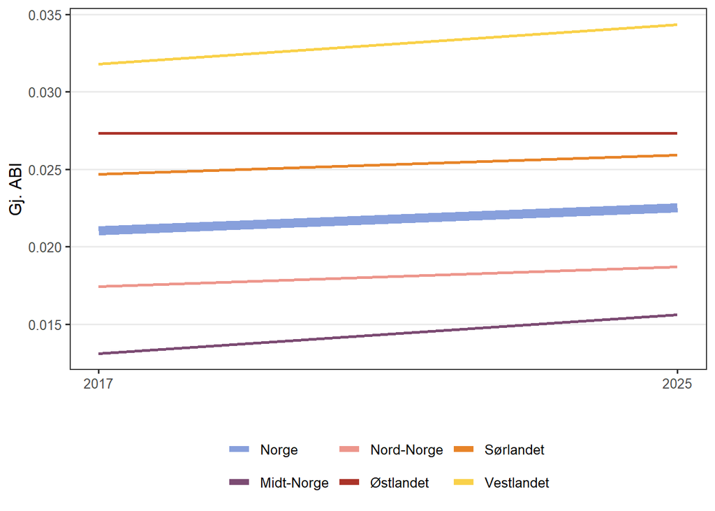

Figure 1: Time series of spatially aggregeed human infrastructure or land use intensity index.

```r
region_labels <- c(
  "1" = "Østlandet", "2" = "Sørlandet", "3" = "Vestlandet",
  "4" = "Midt-Norge", "5" = "Nord-Norge", "Norge" = "Norge"
)
region_levels <- c("Norge", "Midt-Norge", "Nord-Norge", "Østlandet", "Sørlandet", "Vestlandet")

region_cols <- setNames(
  MetBrewer::met.brewer("Archambault", n = length(region_levels)),
  region_levels
)

plot_data <- abi |>
  dplyr::mutate(
    region_name = dplyr::recode(area, !!!region_labels),
    series_type = dplyr::if_else(area == "Norge", "Norge", "Region")
  ) |>
  dplyr::group_by(year, area, series_type) |>
  dplyr::mutate(region_name = factor(area, levels = region_levels))

ggplot2::ggplot(
  plot_data,
  ggplot2::aes(x = year, y = value, colour = region_name, group = region_name)
) +
  ggplot2::geom_line(
    ggplot2::aes(linewidth = series_type)
  ) +
  ggplot2::scale_colour_manual(values = region_cols, name = NULL) +
  ggplot2::scale_linewidth_manual(values = c(Norge = 3, Region = 1), guide = "none") +
  ggplot2::scale_x_continuous(breaks = c(2017, 2025))+
  ggplot2::theme_bw(base_size = 12) +
  ggplot2::theme(
    legend.position    = "bottom",
    legend.box         = "horizontal",
    panel.grid.minor   = ggplot2::element_blank(),
    panel.grid.major.x = ggplot2::element_blank()
  ) +
  ggplot2::guides(
    colour = ggplot2::guide_legend(
      nrow = 2,
      override.aes = list(size = 0.7, linewidth = 2)
    )) +
  ggplot2::labs(y = "Gj. ABI", x = "")
```

## 11. Export file

```r
ggsave(here::here("img/ABI.png"))
```

## 12. Author contributions

This workflow is the work of a single author, but I would like to acknowledge the help from Erik Stange in providing and explaining the datasets.

**Session Info**

This information is mainly aimed at developers that need to recreate the R environment that produced the html. Important note: this information is about the R session that was running when the html was rendered, and if some of the code chunks were not evaluated when the html was rendered, they may have been executed in a different environment.

## References

Erikstad, Lars, Trond Simensen, Vegar Bakkestuen, and Rune Halvorsen. 2023. “Index Measuring Land Use Intensity—A Gradient-Based Approach.” *Geomatics* 3 (1): 188–204. https://doi.org/10.3390/geomatics3010010.